# Smoothing in the time and frequency domains

### 8.1.1 Question: What are the x-axis units?

### 8.1.2 Question: Comment on what you learn from comparing these smoothed periodograms.

- Note: the `ts` class can also be useful for helping R choose other plotting options in a way appriate for time series. For example,

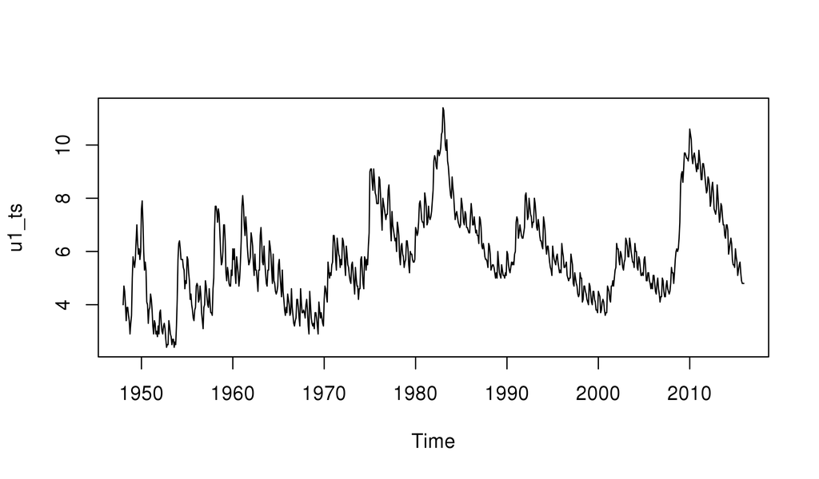

```r
plot(u1_ts)
```

- Note: For a report, we should add units to plots. Also, extra details (like `bandwith` in the periodogram plot) should be explained or removed.

## 8.2 The transfer function (or frequency response function) of a smoother

- The ratio of the periodograms of the smoothed and unsmoothed time series is called the **transfer function** or **frequency response function** of the smoother.
- We can infer the frequency response of the smoother used by Bureau of Labor Statistics to deseasonalize the unemployment data.

```r
s <- spectrum(ts.union(u1_ts,u2_ts),plot=FALSE)
```

- We need to figure out how to extract the bits we need from `s`

```r
names(s)
```

```
##  [1] "freq"      "spec"      "coh"       "phase"     "kernel"
##  [6] "df"        "bandwidth" "n.used"    "orig.n"    "series"
## [11] "snames"    "method"    "taper"     "pad"       "detrend"
## [16] "demean"
```

```r
dim(s$spec)
```

```
## [1] 432   2
```

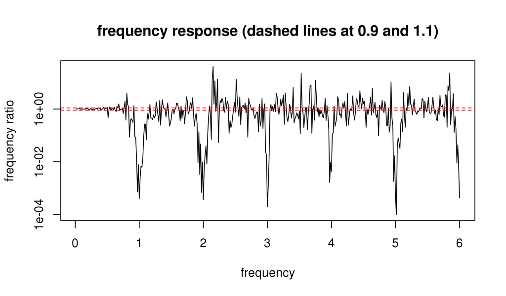

```r
plot(s$freq,s$spec[,2]/s$spec[,1],type="l",log="y",
  ylab="frequency ratio", xlab="frequency",
  main="frequency response (dashed lines at 0.9 and 1.1)")
abline(h=c(0.9,1.1),lty="dashed",col="red")
```

### 8.2.1 Question: What do you learn from this frequency response plot?

### 8.2.2 Loess smoothing

- Loess is a **Local linear regression** approach (perhaps an acronym for LOcally EStimated Surface?)
- The basic idea is quite simple: at each point in time, we carry out a linear regression (e.g., fit a constant, linear or quadratic polynomial) using only points close in time. Thus, we can imagine a moving window of points included in the regression.
- `loess` is an R implementation, with the fraction of points included in the moving window being scaled by the `span` argument.
- Let’s choose a value of the span that visually separates long term trend from business cycle.

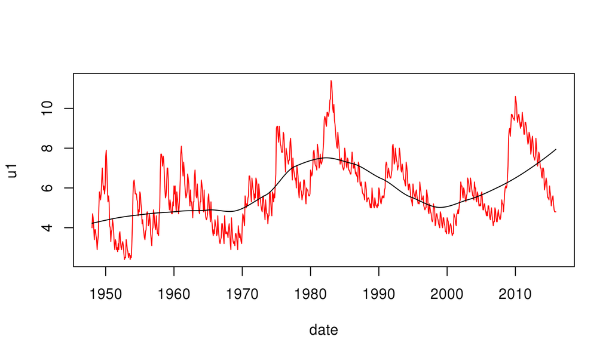

```r
u1_loess <- loess(u1~date,span=0.5)
plot(date,u1,type="l",col="red")
lines(u1_loess$x,u1_loess$fitted,type="l")
```

- Now, we can compute the frequency response function for what we have done.

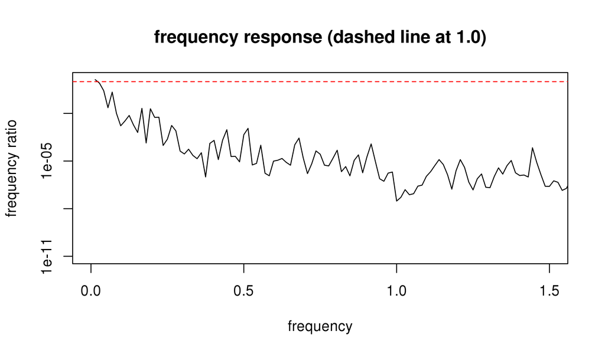

```r
s2 <- spectrum(ts.union(
  u1_ts,ts(u1_loess$fitted,start=1948,frequency=12)),
  plot=FALSE)
plot(s2$freq,s2$spec[,2]/s$spec[,1],type="l",log="y",
  ylab="frequency ratio", xlab="frequency", xlim=c(0,1.5),
  main="frequency response (dashed line at 1.0)")
abline(h=1,lty="dashed",col="red")
```

### 8.2.3 Question: Describe the frequency domain behavior of this filter.